# (Ford GoBike System Exploration)

## by (Salma Hesham Salah Abdelhalim)

## Preliminary Wrangling

> This dataset includes information about rides made in nike-sharing system in San Fransisco.

## Now we will investigate some parameters from our dataset:

### Now, we will see how likely it is that the people share bikes till the end of the trip.

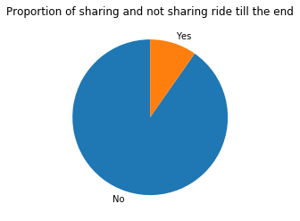

```python
bike_share = df.bike_share_for_all_trip.value_counts()
plt.pie(bike_share, labels=bike_share.index, startangle=90);
plt.title('Proportion of sharing and not sharing ride till the end');
```

Most people don't share bikes till the end of the trips.

### Here, we will the presence of each gender in our dataset.

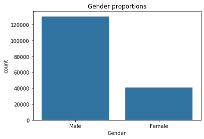

```python
sb.countplot(data=df, x='member_gender', color=sb.color_palette()[0]);
plt.title('Gender proportions');
plt.xlabel('Gender');
```

There are a lot more males than females.

## In this section, we will investigate relationships between pairs in our data:

### We will see how likely each gender will share a bike trip till the end.

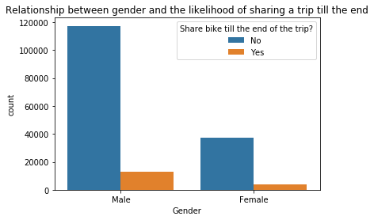

```python
sb.countplot(data = df, x = 'member_gender', hue = 'bike_share_for_all_trip');
plt.title('Relationship between gender and the likelihood of sharing a trip till the end');
plt.xlabel('Gender');
plt.legend(title='Share bike till the end of the trip?');
```

This chart shows that both males and females tend to not share a trip till the end. The high no bar for males is because the number of males is larger than females, but does not necessarily mean that the proportion of males who don't share a trip till the end is higher that the proportion of females.

### We will see now if the relationship between duration of the trip and the likelihood of bike sharing for the whole trip.

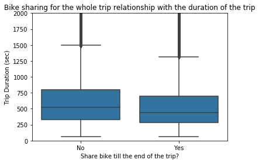

```python
sb.boxplot(data=df, x='bike_share_for_all_trip', y='duration_sec', color=sb.color_palette()[0]);
plt.title('Bike sharing for the whole trip relationship with the duration of the trip');
plt.xlabel('Share bike till the end of the trip?');
plt.ylabel('Trip Duration (sec)');
plt.ylim(0, 2000);
```

We observe here that the duration doesn't really affect the variable of sharing the whole trip or not as the two plots are quite similar with the probability of no being higher. Here, we had to zoom in to the durations less than 2000 seconds tobetter observe the plot.

### We will see here if the year of birth affects the bike sharing for the whole trip decision.

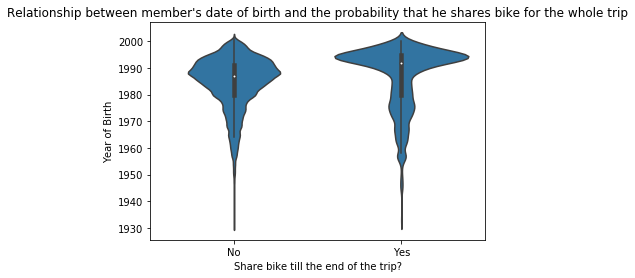

```python
sb.violinplot(data=df, x='bike_share_for_all_trip', y='member_birth_year', color=sb.color_palette()[0]);
plt.title("Relationship between member's date of birth and the probability that he shares bike for the whole trip");
plt.xlabel('Share bike till the end of the trip?');
plt.ylabel('Year of Birth');
```

The median of the yes plot is higher than the no plot. The number of people sharing the whole trip is the largest in years between 1990 and 2001, while the number people who don't share the whole trip is the largest in years between 1985 and 1990.

### We will take a look at the relationship between the gender and the duration of the trip.

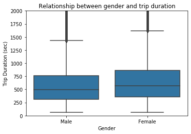

```python
sb.boxplot(data=df, x='member_gender', y='duration_sec', color=sb.color_palette()[0]);
plt.title('Relationship between gender and trip duration');
plt.xlabel('Gender');
plt.ylabel('Trip Duration (sec)');
plt.ylim(0, 2000);
```

Females tend to take longer trips than males.

### Relation between age, represented by the year of birth, and trip duration

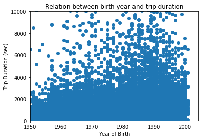

```python
plt.scatter(data=df, x='member_birth_year', y='duration_sec');
plt.xlabel('Year of Birth');
plt.xlim(1950);
plt.ylabel('Trip Duration (sec)');
plt.ylim(0, 10000);
plt.title('Relation between birth year and trip duration');
```

More people contribute are year of birth increases and they a little longer trip durations.

## We will see here relatioships between three variables:

### We will investigate the relationship between the duration of trip, gender, and the likelihood that people share bikes till the end of the trip.

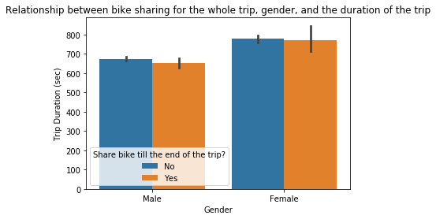

```python
sb.barplot(data=df, x='member_gender', y='duration_sec', hue='bike_share_for_all_trip');
plt.title('Relationship between bike sharing for the whole trip, gender, and the duration of the trip');
plt.ylabel('Trip Duration (sec)');
plt.xlabel('Gender');
plt.legend(title='Share bike till the end of the trip?', loc='best');
```

Females tend to take longer trips than males. The duration doesn't affect the bike sharing for the whole trip paremeter in females. Males tend to have shorter trip durations are are slightly more likely to not share bike till the end of the trip as the duration gets longer.

### We will see now the relation between the duration of the trip, the age of the member resembeled in the birth year, and the possibility that a trip is hared till the end.

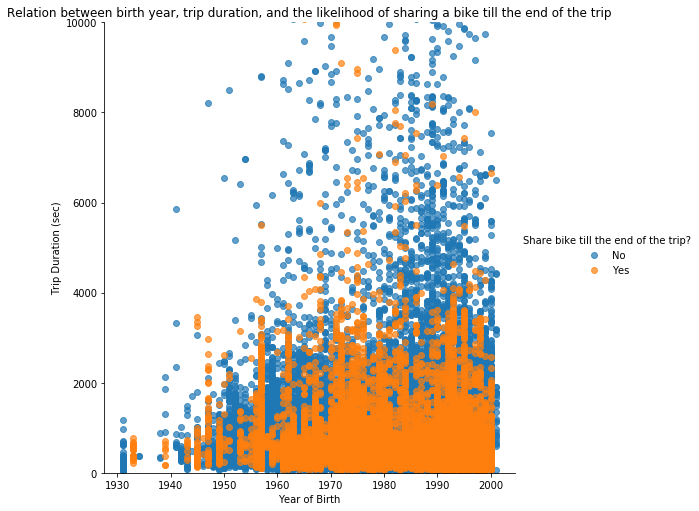

```python
p = sb.FacetGrid(data=df, hue='bike_share_for_all_trip', height=7);
p.map(plt.scatter, 'member_birth_year', 'duration_sec', alpha=0.7);
plt.ylim(0, 10000);
p.set_axis_labels('Year of Birth', 'Trip Duration (sec)');
p.add_legend(title='Share bike till the end of the trip?');
plt.title('Relation between birth year, trip duration, and the likelihood of sharing a bike till the end of the trip');
```

The contribution of younger people is larger. As the trip duration increases, people tend to not share a bike till the end of the trip.